# Método da Transformação Inversa - Aula de Exercícios

Disciplina: GET00204 - Estatística Computacional 2

# Motivação

Muitas distribuições podem ser geradas a partir de uma variável uniforme em $(0,1)$. O método da transformação inversa é um dos procedimentos mais importantes da simulação estatística baseado neste princípio.

# Método da Transformação Inversa para V.A. Contínuas

Assim como no caso discreto, é possível gerar valores de uma v.a. contínua a partir de sua função de distribuição (acumulada).

Lembre-se que, se $X$ é v.a. contínua com função de distribuição $F_X$, então, $F_X$ é uma função absolutamente contínua e, portanto, inversível.

O método da transformação inversa no caso contínuo é, portanto, baseado no inverso da função de distribuição, baseando-se no seguinte resultado teórico.

## Proposição

Seja $U$ uma variável aleatória contínua com distribuição uniforme no intervalo $(0, 1)$. Para qualquer função de distribuição contínua $F$, cuja inversa é denotada por $F^{-1}$, a variável aleatória $X$ definida por
$$X = F^{-1}(U)$$
possui distribuição $F$.

**Demonstração:**

*Seja $F_X$ a função de distribuição de $X = F^{-1}(U)$. Então*
$$\begin{align}
F_X(x) = P(X \le x)
= P(F^{-1}(U) \le x)
\end{align}$$

*Agora, visto que $F$ é função de distribuição de uma v.a. contínua, segue que $F(x)$ é uma função monotonamente crescente de $x$, e portanto a desigualdade “$a \le b$” é equivalente à desigualdade “$F(a) \le F(b)$”. Desse modo, segue que*

$$\begin{align*}
F_X(x) &= P(\;F(F^{-1}(U))\;) \le F(x)\} \\
&= P(U \le F(x)) \\
&= F_U(\;F(x)\;)\underbrace{=}_{\star} F(x)
\end{align*}$$
$^\star$ uma vez que $U \sim \text{U}(0,1) \Rightarrow F_U(u) = u, \;0<u<1 \quad\quad \square$.

A proposição acima garante que podemos gerar uma variável aleatória $X$ a partir da função de distribuição contínua $F$ gerando um número aleatório $U$ e então definindo $X = F^{-1}(U)$.

### Observação

*Lema:*

*Se $U \sim \text{U}(0,1)$, então a v.a. $F^{-}(U)$ tem função de distribuição $F$.*

## Algoritmo

1. Gere um valor $u$ de $U \sim \text{U}(0,1)$.
2. Tome $x = F_X^{-1}(u)$.

Repita os passos 1 e 2 quantas vezes forem necessárias até obter a amostra do tamanho desejado.

## Exemplo 1

Suponha que queremos gerar uma variável aleatória $X$ que possui a função de distribuição
$$F_X(x) = x^a, \quad 0 < x <
1.$$
Utilize o Método da Transformação Inversa para obter uma amostra de $X$.

**Solução:**

Se definirmos $x = F_X^{-1}(u)$, então
$$u = F(x) = x^n \quad \text{ou,
equivalentemente,} \quad x = u^{1/a}.$$

## Algoritmo 1

1. Gere um valor $u$ de $U \sim \text{U}(0,1)$.
2. Tome $x = u^{1/n}$.

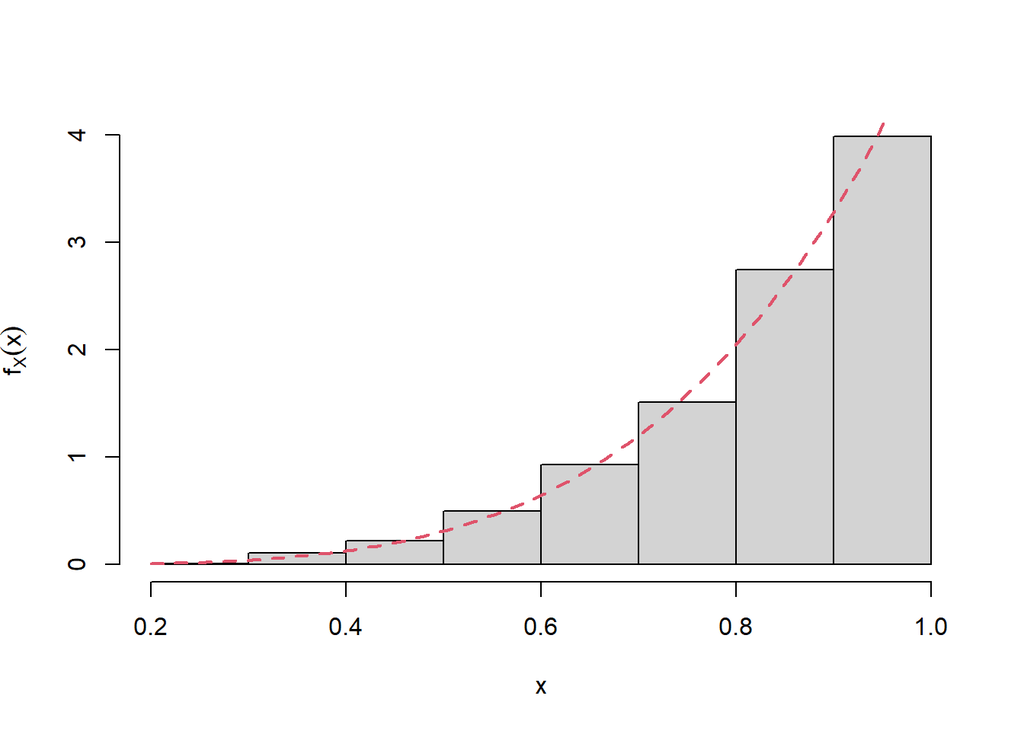

```r
n = 1000
u = runif(n)

a = 5
x = u^{1/a}

hist(x,prob=TRUE,main="",ylab=expression(f[X](x)))

dens = function(x,a){
  a*x^(a-1)
}
curve(dens(x,a=a),add=T,col=2,lwd=2,lty=2)
```

# Visitando algumas Distribuições Contínuas

## Exemplo 2: Distribuição Exponencial

Simular valores de uma v.a. $X \sim \text{Exp}(\lambda)$, para $\lambda$ fixo.

**Solução:**

Se $X$ é uma variável aleatória exponencial com média $1/\lambda$, então sua função de distribuição é dada por
$$F_X(x) = 1 - e^{-\lambda x}.$$
Se definirmos $x = F_X^{-1}(u)$, então
$$u = F_X(x) = 1 - e^{-\lambda x} \qquad
\Leftrightarrow \qquad 1 - u = e^{-\lambda x} \qquad \Leftrightarrow
\qquad x = -\dfrac{\log(1 - u)}{\lambda}.$$

## Algoritmo 2

1. Gere um valor $u$ de $U \sim \text{U}(0,1)$.
2. Tome $x = -\dfrac{\log(1 - u)}{\lambda}$.

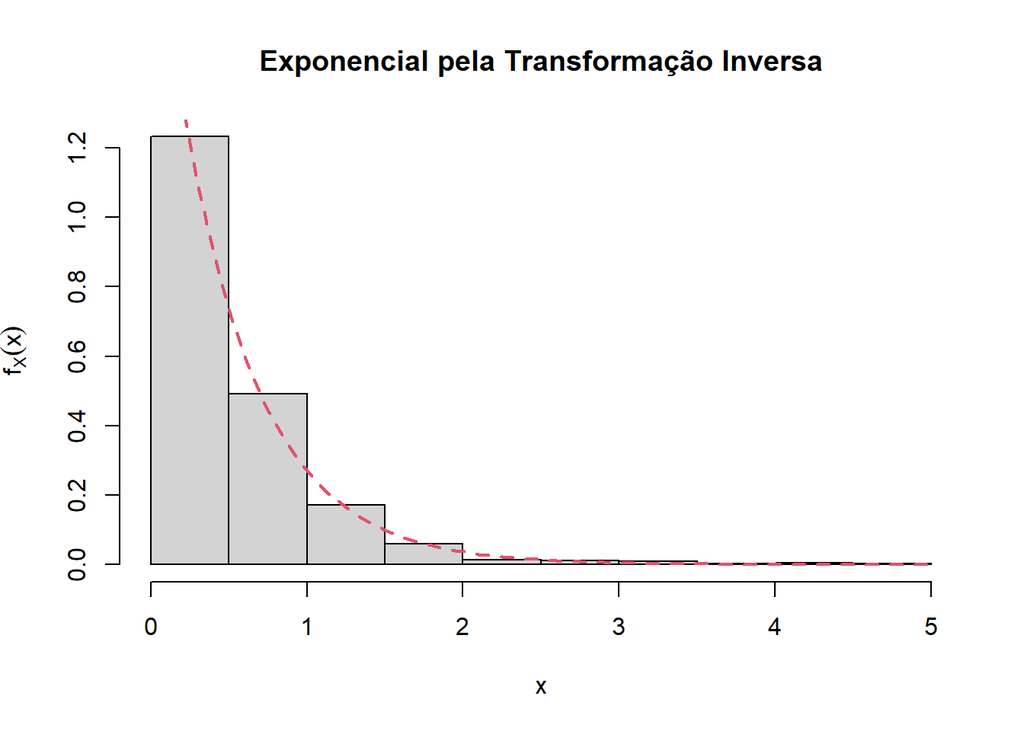

```r
rexp.inv = function(n,lambda){
  u = runif(n)

  x = -log(1-u)/lambda
}

lambda = 2
x = rexp.inv(1000,lambda)

hist(x,prob=TRUE,ylab=expression(f[X](x)),
     main="Exponencial pela Transformação Inversa")
curve(dexp(x,lambda),
      add=TRUE,col=2,lwd=2,lty=2)
```

## Exemplo 3: Distribuição Erlang

Suponha que queremos gerar o valor de uma variável aleatória $X \sim \text{Erlang}(k,\lambda) \equiv \text{Gama}(k, \lambda)$, $k$ natural.

Utilize o Método da Transformação Inversa para obter uma amostra de $X$.

**Solução:**

Como a função de distribuição $F_X$ de tal variável aleatória é dada por
$$F_X(x) = \int_{0}^{x}
\frac{\lambda^k}{(k-1)!} e^{-\lambda y}y^{k-1} \, dy$$
não é possível obter uma expressão em forma fechada para sua inversa. No entanto, usando o resultado de que uma variável aleatória gama $(n, \lambda)$ pode ser considerada como a soma de $k$ exponenciais independentes, cada uma com taxa $\lambda$ (veja a Seção 2.9 do Capítulo 2 de Ross (2022)), podemos fazer uso do Exemplo 2 para gerar $X$.

Especificamente, podemos gerar $X$ gerando $k$ números aleatórios $U_1, \dots, U_k$ e então definindo
$$\begin{align*}
X &= \sum_{i=1}^k-\frac{1}{\lambda} \log (1-U_i)
= -\frac{1}{\lambda} \sum_{i=1}^k\log (1-U_i)
= -\frac{1}{\lambda} \log\left(\prod_{i=1}^k(1-U_i)\right)
\end{align*}$$
onde o uso da identidade $\sum_{i=1}^{k} \log y_i = \log(y_1 \dots y_k)$ economiza tempo computacional, pois requer apenas um cálculo logarítmico em vez de $n$ cálculos.

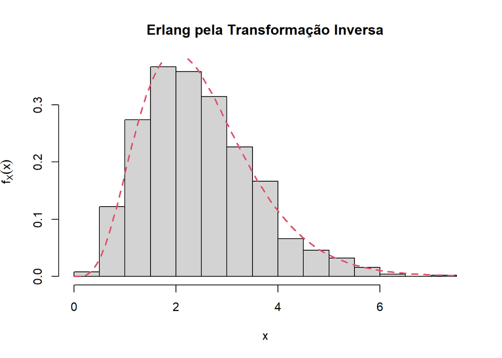

```r
rerlang.inv = function(n,k,lambda){
  for(i in 1:n){
    u = runif(k)
    x[i] = -log(prod(1-u))/lambda
  }
  x
}

k = 5
lambda = 2
x = rerlang.inv(1000,k,lambda)

hist(x,prob=TRUE,ylab=expression(f[X](x)),
     main="Erlang pela Transformação Inversa")
curve(dgamma(x,k,lambda),
      add=TRUE,col=2,lwd=2,lty=2)
```

# Exercícios

1. Derive a transformação inversa para a distribuição Uniforme $(a,b)$.
2. Derive a transformação inversa da distribuição Cauchy.
3. Derive a transformação inversa da distribuição Pareto e implemente uma função que gere valores de acordo com este modelo.
4. Compare as amostras geradas pelo método inverso com as funções nativas do R.

# Referências

ROSS, Sheldon M. *Simulation*. 6. ed. London: Academic Press, 2022.

ROBERT, Christian P.; CASELLA, George. *Monte Carlo Statistical Methods*. 2. ed. New York: Springer, 2004.